# Presenting the Arthritis Results with R Markdown

R Markdown: Beyond the Basics

Jonas Wallin

# 1 From Plots to a Report

In the Arthritis worked example, we used bar charts, mosaic plots, and waffle plots to display the results of a treatment trial. Here, we will reuse those plots in a guided walkthrough of more advanced R Markdown features. We will build a figure with aligned panels and a shared legend, reuse chunk settings, organize results in tabs, generate text from calculated results, and render several versions of the report from one source file. Each section contains complete code and explains the output it produces.

This example follows the Introduction to R Markdown. Open this `.Rmd` file in RStudio and click **Knit** to produce the HTML report. You can also download the source from the **Code** menu at the top of this page. The document contains its own data preparation, so you can knit it without running the original Arthritis example first. We use the same packages as that example, plus **patchwork** for combining plots. Install any missing packages before knitting.

Tabs and code folding are features of the HTML output used here. We will introduce the treatment parameter in the YAML header in the final sections. Until then, both treatment groups remain in the comparison plots.

# 2 Prepare the Data and Save the Plots

The `Arthritis` data contain one row per participant. `Treatment` identifies the treatment arm, and `Improved` records no, some, or marked improvement. We first count the participants in each category and calculate proportions within each treatment arm.

```r
library(tidyverse)
library(vcd)
library(ggmosaic2)
library(waffle)

arthritis_summary <-
  Arthritis %>%
  count(Treatment, Improved, name = "Count") %>%
  group_by(Treatment) %>%
  mutate(Proportion = Count / sum(Count)) %>%
  ungroup()

arthritis_summary
```

```
## # A tibble: 6 × 4
##   Treatment Improved Count Proportion
##   <fct>     <ord>    <int>      <dbl>
## 1 Placebo   None        29      0.674
## 2 Placebo   Some         7      0.163
## 3 Placebo   Marked       7      0.163
## 4 Treated   None        13      0.317
## 5 Treated   Some         7      0.171
## 6 Treated   Marked      21      0.512
```

We use the same named colors for improvement categories in every plot. This makes it easier to recognize the categories when switching between different charts.

```r
improvement_colors <- c("None" = "lightgrey",
                        "Some" = "skyblue",
                        "Marked" = "steelblue")
```

## 2.1 Save the Bar Charts

Previously, we printed plots as soon as we created them. This time, we assign them to objects. The assignment saves a plot without displaying it. Typing its name, such as `count_plot`, in a later chunk displays it there.

```r
count_plot <-
  ggplot(arthritis_summary, aes(Treatment, Count, fill = Improved)) +
  geom_col(color = "white") +
  scale_fill_manual(values = improvement_colors) +
  theme_minimal(base_size = 12) +
  theme(legend.position = "bottom") +
  labs(title = "Participants in each category",
       x = "Treatment arm", y = "Count", fill = "Improvement")

proportion_plot <-
  ggplot(arthritis_summary, aes(Treatment, Proportion, fill = Improved)) +
  geom_col(position = "dodge", color = "white") +
  scale_y_continuous(labels = scales::label_percent()) +
  scale_fill_manual(values = improvement_colors) +
  theme_minimal(base_size = 12) +
  theme(legend.position = "bottom") +
  labs(title = "Improvement within each arm",
       x = "Treatment arm", y = "Proportion", fill = "Improvement")
```

## 2.2 Save the Mosaic and Waffle Plots

The mosaic plot compares both treatment arms. The waffle plot shows only the treated participants, with one square per participant, as in the original example.

```r
mosaic_plot <-
  ggplot(Arthritis) +
  geom_mosaic(aes(x = product(Improved, Treatment), fill = Improved)) +
  scale_fill_manual(values = improvement_colors) +
  theme_minimal(base_size = 12) +
  theme(legend.position = "bottom") +
  labs(x = "Treatment arm", y = "Improvement", fill = "Improvement")
```

```r
treated_counts <-
  arthritis_summary %>%
  filter(Treatment == "Treated")

waffle_plot <-
  ggplot(treated_counts, aes(fill = Improved, values = Count)) +
  geom_waffle(n_rows = 5, flip = TRUE, color = "white", size = 1) +
  coord_equal() +
  scale_fill_manual(values = improvement_colors) +
  theme_minimal(base_size = 12) +
  theme_enhance_waffle() +
  theme(legend.position = "bottom") +
  labs(title = "Treated participants", fill = "Improvement",
       subtitle = "One square = one participant")
```

# 3 Control Figure Size

There are two different sizes to consider. `fig.width` and `fig.height` set the size of the drawing canvas in **inches**. They affect how much room is available for axes, labels, and legends. `out.width` controls how wide the finished image appears in the document. For example, `out.width = "70%"` displays the image at 70% of the available text width.

These options belong to the chunk that **displays** the plot. We can therefore print the same saved object at different sizes without rebuilding its code.

## 3.1 Change the Drawing Canvas

First, draw the bar chart on a 6-by-4-inch canvas and display it at 70% width.

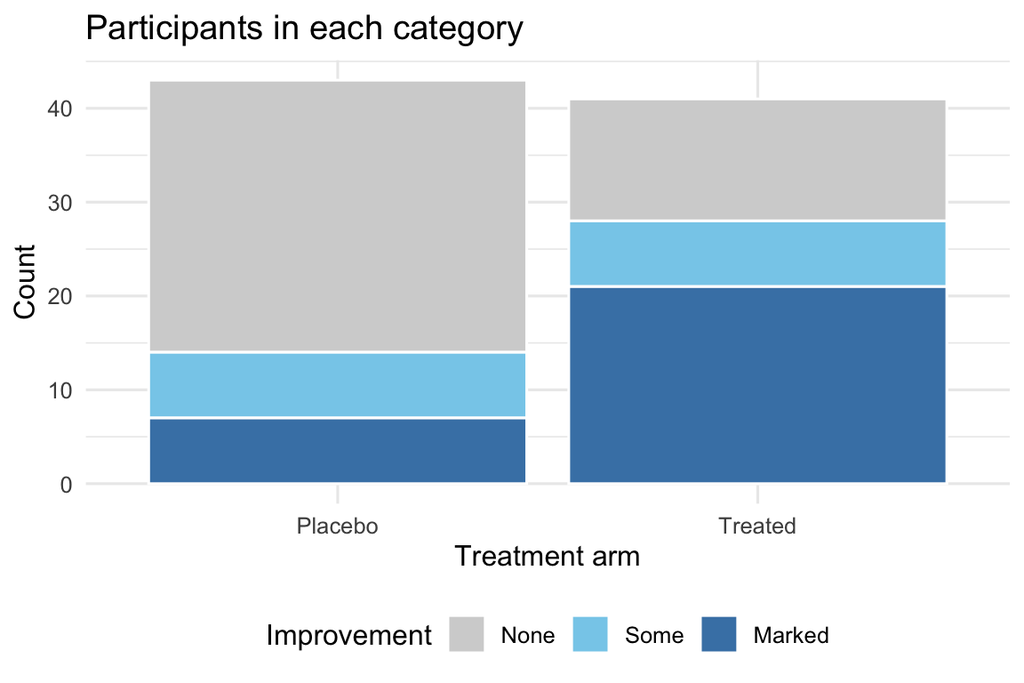

```r
count_plot
```

Now use a 4.5-by-3-inch canvas, keeping the same displayed width and aspect ratio. The text occupies more of the smaller canvas, so it looks larger in the document. There is also less room for the labels and plotting panel.

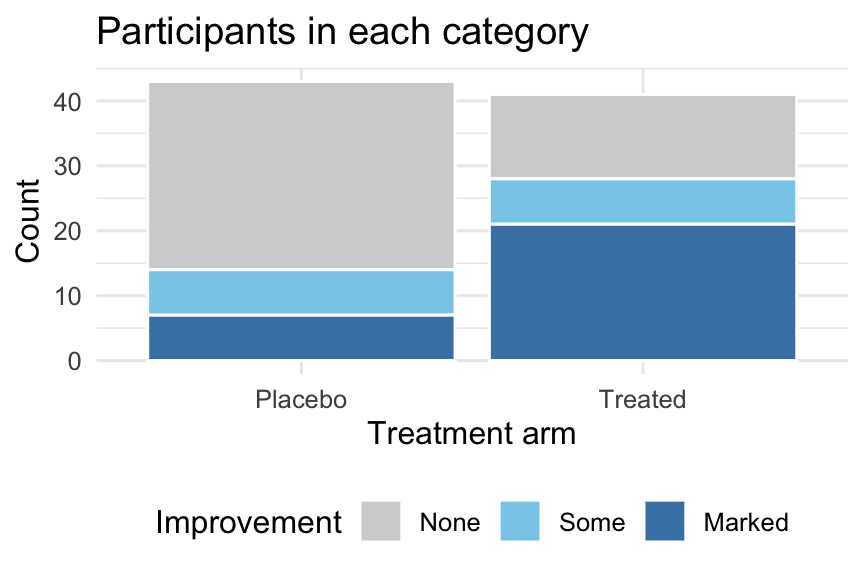

```r
count_plot
```

## 3.2 Change Only the Displayed Width

Return to the 6-by-4-inch canvas, but display the image at 40% width. This shrinks the whole image, including its labels. Changing `out.width` does not rearrange the plot to fit its new displayed size.

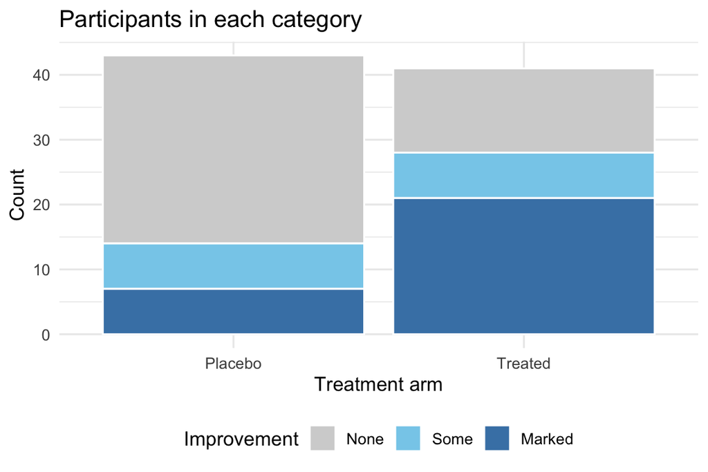

```r
count_plot
```

The first two figures demonstrate a change in the space available for the plot elements. The first and third demonstrate a change in how large the finished image appears. When a legend is cramped, increasing the drawing canvas gives it more room; increasing only the displayed width magnifies the existing layout.

# 4 Put Two Plots Side by Side

We can display the count and proportional bar charts together. Put both plot names in the same chunk, use `fig.show = "hold"` to collect the figures after the code, and give each image half of the available width.

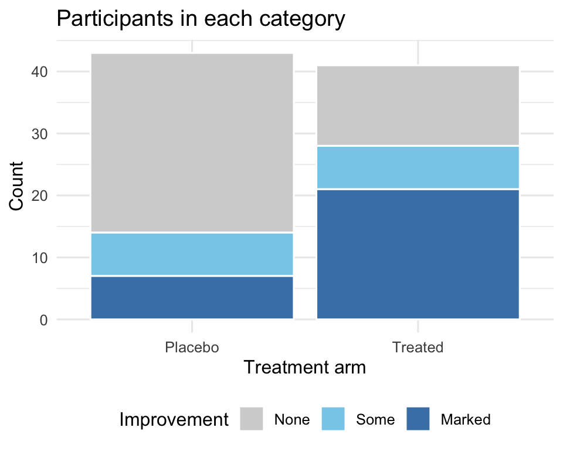

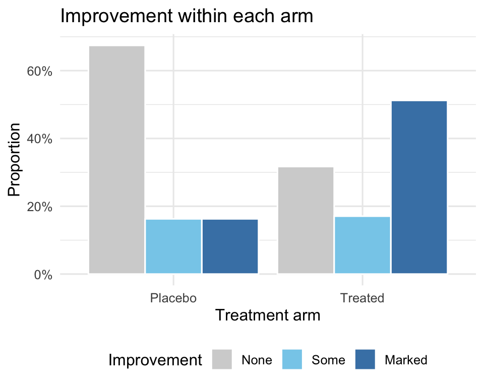

```r
count_plot
proportion_plot
```

The left plot shows how many participants fall in each category. The right plot compares proportions within treatment arms and gives every bar a common baseline. Keep their different vertical scales in mind when reading them.

# 5 Build One Figure with Aligned Panels

The previous chunk places two separate images beside one another. For more control, **patchwork** combines the plots into one figure. It can align their panels, collect matching legends, and add panel labels and a shared title.

First, make versions with shorter titles. Adding labels produces new plot objects; the original `count_plot` and `proportion_plot` remain available.

```r
library(patchwork)

count_panel <- count_plot + labs(title = "Counts")
proportion_panel <- proportion_plot + labs(title = "Proportions")

comparison_plot <-
  (count_panel + proportion_panel +
     plot_layout(ncol = 2, guides = "collect") +
     plot_annotation(title = "Improvement in the Arthritis trial",
                     tag_levels = "A")) &
  theme(legend.position = "bottom")
```

Here, `+` combines the two plots, `guides = "collect"` removes duplicate legends, and `tag_levels = "A"` labels the panels A and B. The `&` operator applies the legend position throughout the combined figure.

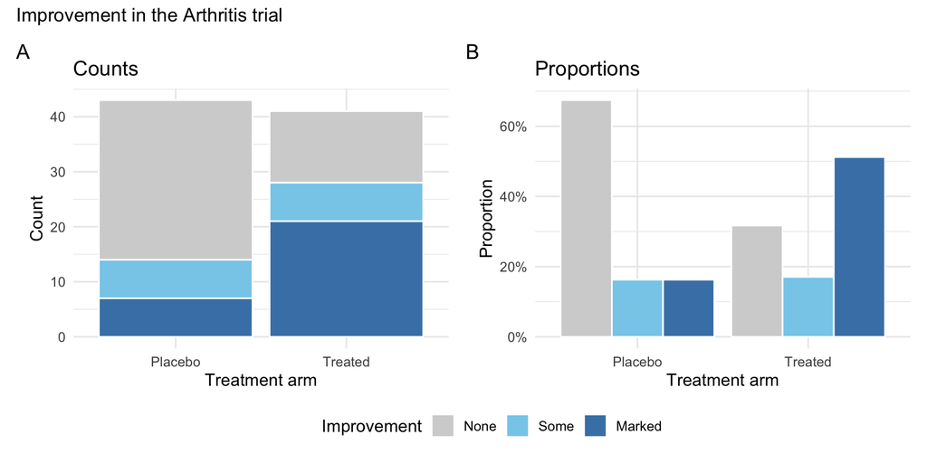

```r
comparison_plot
```

The legend can be shared because both plots use the same category colors, labels, and legend appearance. In particular, both bar layers use white borders. Patchwork compares the rendered guides, so different legend keys can prevent the legends from being merged even when the category labels match.

The panels retain their own vertical scales: counts in A and proportions in B. Combining plots does not make those quantities interchangeable.

# 6 Reuse Figure Settings across Chunks

Repeated figure options can be collected into a named template. We will use the following settings for the individual charts in the next sections:

```r
knitr::opts_template$set(
  report_plot = list(fig.width = 6,
                     fig.height = 4,
                     out.width = "85%")
)
```

Later chunks select this template with `opts.label = "report_plot"`. Changing the template changes all chunks that use it. The template must be defined before those chunks are evaluated.

The order of precedence is **global settings, then the template, then options on the individual chunk**. For example, a chunk with `opts.label = "report_plot", fig.height = 3` uses a 6-by-3-inch canvas and 85% displayed width. This lets a report keep a consistent style while allowing individual figures to use a different shape.

# 7 Organize Related Plots in Tabs

Tabs let readers switch between related results without scrolling past every plot. Add `{.tabset}` to a heading and place the tab headings one level below it. Here, a level-two heading contains three level-three headings:

```markdown
## Choose a Chart {.tabset}

### Bar Chart

### Mosaic Plot

### Waffle Plot
```

Place each plot chunk and its interpretation under the corresponding tab heading. A new heading at the same level as the tabset, or a higher level, ends the tabbed section. The next main section in this document does that.

## 7.1 Choose a Chart

### 7.1.1 Bar Chart

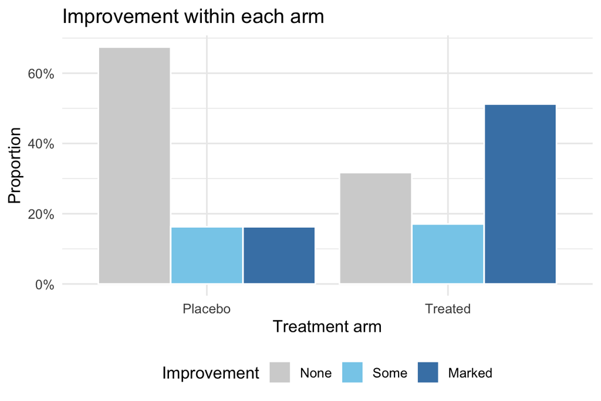

```r
proportion_plot
```

The grouped bars share a baseline, making the improvement proportions easy to compare between treatment arms.

### 7.1.2 Mosaic Plot

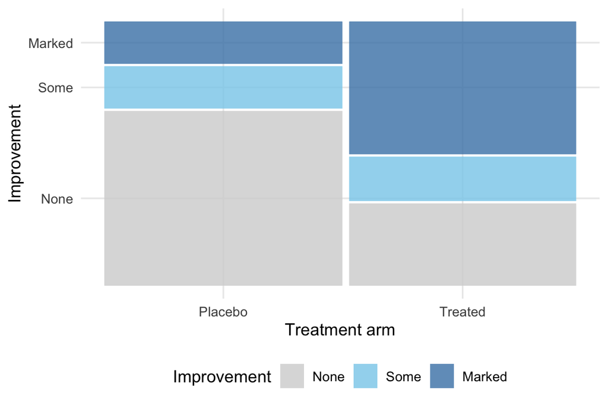

```r
mosaic_plot
```

The widths show the relative sizes of the treatment arms. Within each arm, the segment heights show the improvement proportions. The areas therefore represent shares of all participants.

### 7.1.3 Waffle Plot

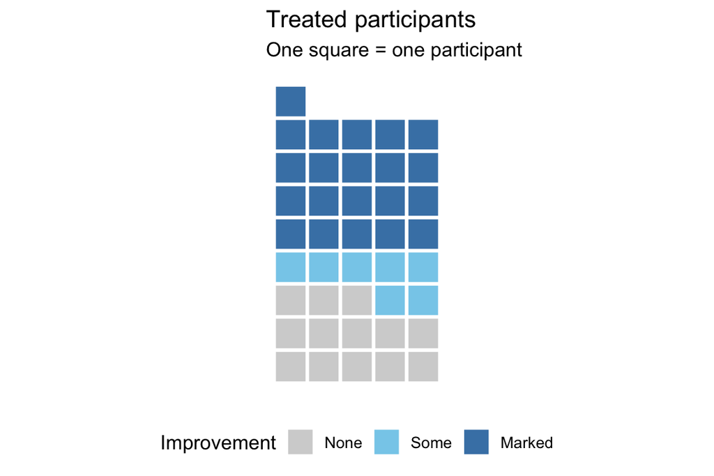

```r
waffle_plot
```

Each square represents one treated participant. This plot describes the treated arm only; comparing treatment arms requires the information shown in the other tabs.

# 8 Let the Text Update with the Data

A report also contains numbers in its sentences. Rather than typing those numbers by hand, we can insert results calculated by R. First, prepare a small summary. Here, **any improvement** means either `Some` or `Marked`.

```r
group_summary <-
  arthritis_summary %>%
  group_by(Treatment) %>%
  summarize(Participants = sum(Count),
            AnyImprovement = sum(Count[Improved != "None"]),
            .groups = "drop") %>%
  mutate(Share = AnyImprovement / Participants)

treated_summary <- filter(group_summary, Treatment == "Treated")
placebo_summary <- filter(group_summary, Treatment == "Placebo")

group_summary %>%
  mutate(Share = scales::percent(Share, accuracy = 0.1)) %>%
  knitr::kable(col.names = c("Treatment arm", "Participants",
                           "Any improvement", "Percentage"))
```

| Treatment arm | Participants | Any improvement | Percentage |
| --- | --- | --- | --- |
| Placebo | 43 | 14 | 32.6% |
| Treated | 41 | 28 | 68.3% |

Inline R uses a backtick, the letter `r`, a space, and an R expression, followed by a closing backtick. Write this sentence in the text of the `.Rmd` file, outside a code chunk:

```markdown
Of the `r treated_summary$Participants` treated participants,
`r treated_summary$AnyImprovement` showed some or marked improvement
(`r scales::percent(treated_summary$Share, accuracy = 0.1)`).
```

When the document is knitted, it becomes:

> Of the 41 treated participants, 28 showed some or marked improvement (68.3%).

For comparison, 14 of the 43 placebo participants showed some or marked improvement (32.6%). These are descriptive summaries of the observed outcomes.

The same calculated values now feed the table and the prose. The R expressions must refer to objects created in an earlier chunk. RStudio’s Knit button evaluates the document from top to bottom in a fresh R session, so objects that exist only in your Console are not available there.

## 8.1 Generate a Whole Paragraph from R

Inline R works well for individual values. A longer piece of text can also depend on the results. Here, we calculate the difference in improvement proportions and choose the wording according to its sign.

```r
difference_pp <- 100 * (treated_summary$Share - placebo_summary$Share)
difference_label <- scales::number(abs(difference_pp), accuracy = 0.1)

comparison_text <- if (difference_pp > 0) {
  paste("The percentage with some or marked improvement was",
        difference_label, "percentage points higher in the treated arm.")
} else if (difference_pp < 0) {
  paste("The percentage with some or marked improvement was",
        difference_label, "percentage points lower in the treated arm.")
} else {
  "The percentage with some or marked improvement was equal in both arms."
}
```

We can now emit Markdown from a code chunk. `results = "asis"` tells knitr to pass the text to the document as Markdown, so the asterisks produce bold text and the blank line ends the paragraph. Without that option, the text would appear as ordinary console output.

```r
cat("**Observed comparison.** ", comparison_text, "\n\n", sep = "")
```

**Observed comparison.** The percentage with some or marked improvement was 35.7 percentage points higher in the treated arm.

The difference is in **percentage points**: we subtract two percentages. It is a descriptive comparison, without an uncertainty interval. The wording updates when the calculated difference changes, including when its sign changes.

# 9 Let the Reader Show or Hide the Code

The YAML header of this document includes the following output settings:

```yaml
output:
  bookdown::html_document2:
    code_folding: show
    code_download: true
```

With `code_folding: show`, code is visible initially and the reader can hide individual code blocks or use the **Code** menu to hide them all. Change the setting to `code_folding: hide` if you want the document to open with its code collapsed. The plots and tables remain visible in either case.

Keep `echo = TRUE` for code you want readers to be able to reveal. `echo = FALSE` runs the chunk but leaves its source out of the displayed page, so a folding button cannot reveal it. `include = FALSE`, used for the setup chunk, runs the code while hiding both the code and its output.

`code_download: true` adds a download of the complete `.Rmd` source to the **Code** menu, including chunks hidden from the page. This is useful when sharing a worked example that readers should be able to reproduce.

## 9.1 Collapse One Chunk Initially

A report may show most code while initially hiding a long plotting chunk. With `code_folding: show`, the chunk option `class.source = "fold-hide"` collapses just that chunk. Its plot is still displayed, and the reader can reveal the code with the button above it.

The parameterized waffle chunk below uses this option. It keeps `echo = TRUE`, so the source is still present in the HTML. The **Show All Code** command can also reveal it.

# 10 Select a Treatment Group with a Parameter

A parameter lets us reuse the document with a different input. The YAML header already defines one called `treatment`, with two possible choices:

```yaml
params:
  treatment:
    label: "Treatment group for the final waffle plot"
    value: "Treated"
    input: select
    choices: ["Treated", "Placebo"]
```

Inside an R chunk, its value is available as `params$treatment`. We use it below to select the participants for a new waffle plot and calculate the numbers for its accompanying text.

```r
selected_counts <-
  arthritis_summary %>%
  filter(Treatment == params$treatment)

selected_summary <-
  group_summary %>%
  filter(Treatment == params$treatment)
```

The selected arm is **Treated**, containing **41 participants**. Of these, 28 showed some or marked improvement (68.3%).

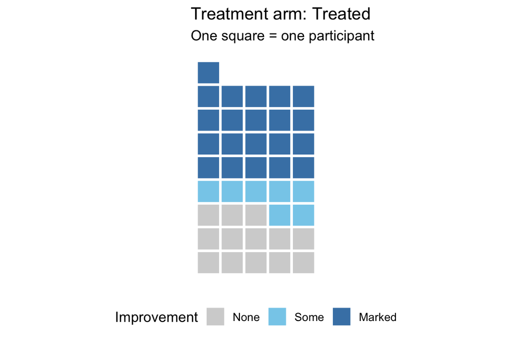

```r
ggplot(selected_counts, aes(fill = Improved, values = Count)) +
  geom_waffle(n_rows = 5, flip = TRUE, color = "white", size = 1) +
  coord_equal() +
  scale_fill_manual(values = improvement_colors) +
  theme_minimal(base_size = 12) +
  theme_enhance_waffle() +
  theme(legend.position = "bottom") +
  labs(title = paste("Treatment arm:", params$treatment),
       subtitle = "One square = one participant", fill = "Improvement")
```

In RStudio, **Knit with Parameters**, available from the arrow beside **Knit**, opens a selection dialog. Choosing `Placebo` and knitting updates the selected group’s text and final waffle plot together. Ordinary **Knit** uses the default value in the YAML header. The earlier comparison plots continue to show both arms, and the earlier treated-only waffle continues to show the treated arm.

The parameter is chosen **before rendering**. It is not an interactive selector inside the finished HTML report.

# 11 Generate Both Report Versions Automatically

A short loop can render the document once for each treatment arm. The code below is run from the **Console**, with the project’s root directory as the working directory. Its chunk has `eval = FALSE` because rendering this file from inside itself would start another render recursively.

```r
for (treatment in c("Treated", "Placebo")) {
  rmarkdown::render(
    "worked-examples/arthritis-rmarkdown.Rmd",
    params = list(treatment = treatment),
    output_file = paste0("arthritis-rmarkdown-", tolower(treatment), ".html"),
    envir = new.env()
  )
}
```

Each call receives its own evaluation environment and a distinct output filename. The files are written beside the source file, keeping the default `arthritis-rmarkdown.html` preview available.

The final section of the two versions contains the following results, taken from the same summaries used throughout the report:

```r
group_summary %>%
  mutate(File = paste0("arthritis-rmarkdown-",
                       tolower(as.character(Treatment)), ".html")) %>%
  select(File, Participants, AnyImprovement) %>%
  knitr::kable(col.names = c("Output file", "Squares in final waffle",
                           "Participants with any improvement"))
```

| Output file | Squares in final waffle | Participants with any improvement |
| --- | --- | --- |
| arthritis-rmarkdown-placebo.html | 43 | 14 |
| arthritis-rmarkdown-treated.html | 41 | 28 |

The final waffle contains 41 squares in the treated version and 43 in the placebo version. The selected-group prose, title, and plot update from the same parameter. The earlier two-arm comparisons are shared by both reports.

# 12 Further Reading

The R Markdown Cookbook explains [figure sizes](https://bookdown.org/yihui/rmarkdown-cookbook/figure-size.html), [side-by-side plots](https://bookdown.org/yihui/rmarkdown-cookbook/figures-side.html), and [HTML tabs](https://bookdown.org/yihui/rmarkdown-cookbook/html-tabs.html). The R Markdown guide also describes [knitting with parameters](https://bookdown.org/yihui/rmarkdown/params-knit.html).